# Case_Study_2

Robert Derner

12/7/2021

[Link](https://smu.zoom.us/rec/play/n4I_gxBul9x6l0eqhvpHsmFpAwzIzmpcFZ3wRvy7FUutJ_6SSmRVyWtLGUXYXvzTOOIcFhxcNsnJwnIH.r2k03etIa08uOa87) to recorded presentation.

## Read and tidy the data

Load the necessary packages

```r
library(tidyverse)
library(e1071)
library(caret)
library(olsrr)
library(viridis)
library(ggridges)
library(moonBook)
library(webr)
```

Read the data

```r
attr <- read_csv('https://raw.githubusercontent.com/ReuvenDerner/CaseStudy2DDS/main/CaseStudy2.csv', show_col_types=F)
```

Study the data: 870 rows (observations) and 36 columns (variables). First 10 rows are printed to allow reader to click through the columns.

```r
dim(attr)
```

```
## [1] 870  36
```

```r
spec(attr)
head(attr, n=10)
```

```
## # A tibble: 10 x 36
##       ID   Age Attrition BusinessTravel    DailyRate Department DistanceFromHome
##    <dbl> <dbl> <chr>     <chr>                 <dbl> <chr>                 <dbl>
##  1     1    32 No        Travel_Rarely           117 Sales                    13
##  2     2    40 No        Travel_Rarely          1308 Research ~               14
##  3     3    35 No        Travel_Frequently       200 Research ~               18
##  4     4    32 No        Travel_Rarely           801 Sales                     1
##  5     5    24 No        Travel_Frequently       567 Research ~                2
##  6     6    27 No        Travel_Frequently       294 Research ~               10
##  7     7    41 No        Travel_Rarely          1283 Research ~                5
##  8     8    37 No        Travel_Rarely           309 Sales                    10
##  9     9    34 No        Travel_Rarely          1333 Sales                    10
## 10    10    34 No        Travel_Frequently       653 Research ~               10
## # ... with 29 more variables: Education <dbl>, EducationField <chr>,
## #   EmployeeCount <dbl>, EmployeeNumber <dbl>, EnvironmentSatisfaction <dbl>,
## #   Gender <chr>, HourlyRate <dbl>, JobInvolvement <dbl>, JobLevel <dbl>,
## #   JobRole <chr>, JobSatisfaction <dbl>, MaritalStatus <chr>,
## #   MonthlyIncome <dbl>, MonthlyRate <dbl>, NumCompaniesWorked <dbl>,
## #   Over18 <chr>, OverTime <chr>, PercentSalaryHike <dbl>,
## #   PerformanceRating <dbl>, RelationshipSatisfaction <dbl>, ...
```

Remove columns with single unique value as they are not useful for EDA or prediction

```r
attr <- attr %>% select(-c('Over18', 'EmployeeCount', 'EmployeeNumber', 'PerformanceRating', 'StandardHours'))
```

Confirm that there are zero NA values

```r
sum(as.numeric(is.na.data.frame(attr)))
```

```
## [1] 0
```

I copied *Attrition* into a new column called *attr10*, replaced “No” with 0 and “Yes” with 1, set class as numeric for aggregate function to calculate attrition percentages.

```r
attr <- attr %>% mutate(attr10 = Attrition, attr10 = replace(attr10, attr10 != "No", 1))
attr <- attr %>% mutate(attr10 = replace(attr10, attr10 != "1", 0))
attr$attr10 <- as.numeric(attr$attr10)
```

## Exploratory Data Analysis

Age

- Distribution is right skewed; possibly log transform prior to modeling
- Age vs attrition is very significant; highest between 18-22 at >50%
- Age vs job role is significant
- Age vs gender and department is about even

```r
# dist of age
hist(attr$Age, breaks=50, main='Distribution of Age', xlab = 'Age')
quantile(attr$Age)
# vs gender, department, job role
boxplot(Age~Gender, data=attr) # insig
boxplot(Age~Department, data=attr) # significant ish
boxplot(Age~JobRole, data=attr) # significant
```

[output not shown]

Attrition (as it relates to personal self/life)

- 140 attrition, 730 no attrition
- vs gender is about even (15% female, 17% male)
- Age vs attrition is very significant; highest between 18-22 at >50%
- Highest for single marital status at 26%
- Increases as distance from home goes up; 15%+ for 12.2+ miles
- Increases as education level goes down
- Highest for hr 27%, tech degree and marketing 20-23% (edu field)
- Highest for sales department at 22%
- Highest for sales rep at 45%, hr/lab tech 20-22% (job role)
- Highest for lowest job level at 26%
- Highest for 5> total working years at 31%
- Highest for 5+ number of companies worked all >20

Attrition (as it relates to work culture)

- Highest for lowest perceived level of job involvement at 47%
- Highest for lowest perceived level of work life balance at 35%
- Highest for overtime at 32%
- Highest for the least (26%) and best (22%) stock option level. Take a closer look
- Highest for lowest perceived level of environment satisfaction at 24%
- Highest for lowest perceived level of job satisfaction at 21%
- Highest for the first 3 years at company. Will exclude this var as it will skew the model bc not all the years have equal representation
- Highest for travel frequently for business travel at 22%
- Highest for first 2 years in current role at 23%
- Highest for lowest relationship satisfaction with manager at 20%
- Higher for increasing years since last promotion. Uneven distribution. Probably should not include this in the model
- Highest for initial year with current manager however it is skewed for 14 year mark. Either remove that value or don’t include variable in model
- Inconclusive for training times last year
- Inconclusive for percent salary hike. Need to look closer against other variables

```r
# attr count. 0 = "No" 1 = "Yes"
attr %>% count(Attrition)
hist(attr$attr10)
# vs gender. insig
aggregate(attr10~Gender, data=attr, mean)
# vs age. sig
attr.age <- aggregate(x = attr$attr10, by = list(cut(attr$Age, 10)), mean)
names(attr.age) <- c('Age', 'Attrition')
ggplot(attr.age, aes(x = Age, y = Attrition)) + geom_bar(stat = "identity")
# vs marital status. sig
attr.mar <- aggregate(attr10~MaritalStatus, data=attr, mean)
ggplot(attr.mar, aes(x = MaritalStatus, y = attr10)) + geom_bar(stat = "identity")
# vs distance from home. sig
attr.dist <- aggregate(x = attr$attr10, by = list(cut(attr$DistanceFromHome, 10)), mean)
names(attr.dist) <- c('dist', 'Attrition')
ggplot(attr.dist, aes(x = dist, y = Attrition)) + geom_bar(stat = "identity")
# education level. sig if comparing lowest and highest edu levels
attr.edu <- aggregate(attr10~Education, data=attr, mean)
ggplot(attr.edu, aes(x = Education, y = attr10)) + geom_bar(stat = "identity")
# education field. sig
attr.eduf <- aggregate(attr10~EducationField, data=attr, mean)
ggplot(attr.eduf, aes(x = EducationField, y = attr10)) + geom_bar(stat = "identity")
# total working years. very sig
hist(log(attr$TotalWorkingYears)) # LOG
attr.work <- aggregate(x = attr$attr10, by = list(cut(attr$TotalWorkingYears, 8)), mean)
names(attr.work) <- c('total', 'Attrition')
ggplot(attr.work, aes(x = total, y = Attrition)) + geom_bar(stat = "identity")
# number of companies worked. sig
attr.ncomp <- aggregate(attr10~NumCompaniesWorked, data=attr, mean)
ggplot(attr.ncomp, aes(x = NumCompaniesWorked, y = attr10)) + geom_bar(stat = "identity")
# vs department. sig
attr.dep <- aggregate(attr10~Department, data=attr, mean)
ggplot(attr.dep, aes(x = Department, y = attr10)) + geom_bar(stat = "identity")
# vs job role. very sig
attr.role <- aggregate(attr10~JobRole, data=attr, mean)
ggplot(attr.role, aes(x = JobRole, y = attr10)) + geom_bar(stat = "identity")
# job level. sig
attr.level <- aggregate(attr10~JobLevel, data=attr, mean)
ggplot(attr.level, aes(x = JobLevel, y = attr10)) + geom_bar(stat = "identity")
```

[output not shown]

```r
# job involvement. very sig
attr.inv <- aggregate(attr10~JobInvolvement, data=attr, mean)
ggplot(attr.inv, aes(x = JobInvolvement, y = attr10)) + geom_bar(stat = "identity")
# job satisfaction. sig
attr.satis <- aggregate(attr10~JobSatisfaction, data=attr, mean)
ggplot(attr.satis, aes(x = JobSatisfaction, y = attr10)) + geom_bar(stat = "identity")
# vs work life balance. very sig
attr.wlb <- aggregate(attr10~WorkLifeBalance, data=attr, mean)
ggplot(attr.wlb, aes(x = WorkLifeBalance, y = attr10)) + geom_bar(stat = "identity")
# years at company. sig but misleading
attr.yrcomp <- aggregate(x = attr$attr10, by = list(cut(attr$YearsAtCompany, 20)), mean)
names(attr.yrcomp) <- c('Years', 'Attrition')
ggplot(attr.yrcomp, aes(x = Years, y = Attrition)) + geom_bar(stat = "identity")
# years in current role
attr.yrcur <- aggregate(x = attr$attr10, by = list(cut(attr$YearsInCurrentRole, 9)), mean)
names(attr.yrcur) <- c('Years', 'Attrition')
ggplot(attr.yrcur, aes(x = Years, y = Attrition)) + geom_bar(stat = "identity")
# vs business travel. sig
attr.travel <- aggregate(attr10~BusinessTravel, data=attr, mean)
ggplot(attr.travel, aes(x = BusinessTravel, y = attr10)) + geom_bar(stat = "identity")
# vs environment satisfaction. sig
attr.env <- aggregate(attr10~EnvironmentSatisfaction, data=attr, mean)
ggplot(attr.env, aes(x = EnvironmentSatisfaction, y = attr10)) + geom_bar(stat = "identity")
# vs overtime. very sig
attr.ot <- aggregate(attr10~OverTime, data=attr, mean)
ggplot(attr.ot, aes(x = OverTime, y = attr10)) + geom_bar(stat = "identity")
# vs stock option level.
attr.stock <- aggregate(attr10~StockOptionLevel, data=attr, mean)
ggplot(attr.stock, aes(x = StockOptionLevel, y = attr10)) + geom_bar(stat = "identity")
# vs percent salary hike. insig. might be related to a diff variable
attr.inc <- aggregate(attr10~PercentSalaryHike, data=attr, mean)
ggplot(attr.inc, aes(x = PercentSalaryHike, y = attr10)) + geom_bar(stat = "identity")
# vs years since last promotion. sig but inconsistent
attr.yrpromo <- aggregate(attr10~YearsSinceLastPromotion, data=attr, mean)
ggplot(attr.yrpromo, aes(x = YearsSinceLastPromotion, y = attr10)) + geom_bar(stat = "identity")
# vs training times last year. sig but inconsistent
attr.train <- aggregate(attr10~TrainingTimesLastYear, data=attr, mean)
ggplot(attr.train, aes(x = TrainingTimesLastYear, y = attr10)) + geom_bar(stat = "identity")
# vs years with current manager. sig but inconsistent
attr.yrman <- aggregate(attr10~YearsWithCurrManager, data=attr, mean)
ggplot(attr.yrman, aes(x = YearsWithCurrManager, y = attr10)) + geom_bar(stat = "identity")
# vs relationship satisfaction w manager. barely sig
attr.mansatis <- aggregate(attr10~RelationshipSatisfaction, data=attr, mean)
ggplot(attr.mansatis, aes(x = RelationshipSatisfaction, y = attr10)) + geom_bar(stat = "identity")
```

[output not shown]

## Analysis

### Identify top three factors that contribute to turnover

1. Overtime
2. Years in current role
3. Job involvement

Ran logistic regression on the three factors which resulted in 665 AIC, over 150 points lower than other models that we ran.

```r
model <- glm(attr10~YearsInCurrentRole+OverTime+JobInvolvement, family=binomial, data=attr)
summary(model)
```

```
##
## Call:
## glm(formula = attr10 ~ YearsInCurrentRole + OverTime + JobInvolvement,
##     family = binomial, data = attr)
##
## Deviance Residuals:
##     Min       1Q   Median       3Q      Max
## -1.5996  -0.5879  -0.4380  -0.2876   3.0430
##
## Coefficients:
##                    Estimate Std. Error z value Pr(>|z|)
## (Intercept)          0.1877     0.3832   0.490    0.624
## YearsInCurrentRole  -0.1448     0.0323  -4.484 7.32e-06 ***
## OverTimeYes          1.4970     0.2002   7.476 7.65e-14 ***
## JobInvolvement      -0.7312     0.1372  -5.328 9.93e-08 ***
## ---
## Signif. codes:  0 '***' 0.001 '**' 0.01 '*' 0.05 '.' 0.1 ' ' 1
##
## (Dispersion parameter for binomial family taken to be 1)
##
##     Null deviance: 767.67  on 869  degrees of freedom
## Residual deviance: 657.18  on 866  degrees of freedom
## AIC: 665.18
##
## Number of Fisher Scoring iterations: 5
```

#### **Overtime**

Of the 71% of employees who do not work overtime, 90% stay. Of the 29% employees to do work overtime, 32% leave.

Set up the dataframe

```r
ot <- attr %>% select(Attrition, OverTime)
ot$Attrition <- ifelse(ot$Attrition == 'Yes', 'Attrition', ot$Attrition)
```

Plot the pie chart

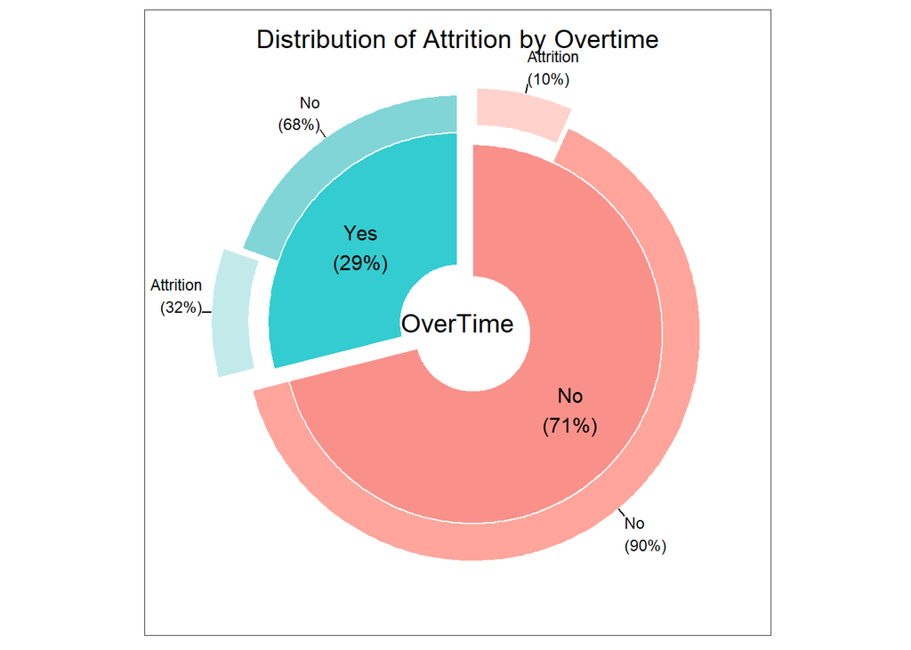

```r
PieDonut(ot,aes(OverTime, Attrition), explode=1,selected=c(1,3),explodeDonut=TRUE, labelposition=1,title="Distribution of Attrition by Overtime")
```

#### **Years in current role**

22% of employees leave the company in their first 3 years if they retained the same role in that duration.

Half violin plot function

```r
"%||%" <- function(a, b) {
  if (!is.null(a)) a else b
}
geom_flat_violin <- function(mapping = NULL, data = NULL, stat = "ydensity",
                             position = "dodge", trim = TRUE, scale = "area",
                             show.legend = NA, inherit.aes = TRUE, ...) {
  layer(
    data = data,
    mapping = mapping,
    stat = stat,
    geom = GeomFlatViolin,
    position = position,
    show.legend = show.legend,
    inherit.aes = inherit.aes,
    params = list(
      trim = trim,
      scale = scale,
      ...
    )
  )
}
#' @rdname ggplot2-ggproto
#' @format NULL
#' @usage NULL
#' @export
GeomFlatViolin <-
  ggproto("GeomFlatViolin", Geom,
          setup_data = function(data, params) {
            data$width <- data$width %||%
              params$width %||% (resolution(data$x, FALSE) * 0.9)

            # ymin, ymax, xmin, and xmax define the bounding rectangle for each group
            data %>%
              group_by(group) %>%
              mutate(ymin = min(y),
                     ymax = max(y),
                     xmin = x,
                     xmax = x + width / 2)
          },

          draw_group = function(data, panel_scales, coord) {
            # Find the points for the line to go all the way around
            data <- transform(data, xminv = x,
                              xmaxv = x + violinwidth * (xmax - x))

            # Make sure it's sorted properly to draw the outline
            newdata <- rbind(plyr::arrange(transform(data, x = xminv), y),
                             plyr::arrange(transform(data, x = xmaxv), -y))

            # Close the polygon: set first and last point the same
            # Needed for coord_polar and such
            newdata <- rbind(newdata, newdata[1,])

            ggplot2:::ggname("geom_flat_violin", GeomPolygon$draw_panel(newdata, panel_scales, coord))
          },

          draw_key = draw_key_polygon,

          default_aes = aes(weight = 1, colour = "grey20", fill = "white", size = 0.5,
                            alpha = NA, linetype = "solid"),

          required_aes = c("x", "y")
  )
# copied from: https://gist.github.com/dgrtwo/eb7750e74997891d7c20
# somewhat hackish solution to: https://twitter.com/EamonCaddigan/status/646759751242620928
# based mostly on copy/pasting from ggplot2 geom_violin source:  https://github.com/hadley/ggplot2/blob/master/R/geom-violin.r
```

Plot the data

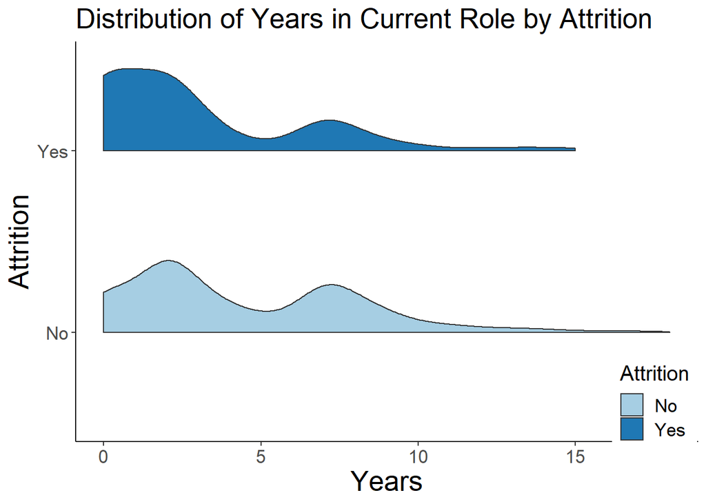

```r
ggplot(attr, aes(Attrition, YearsInCurrentRole, fill=Attrition)) +
    geom_flat_violin() +
    coord_flip() +
    labs(title='Distribution of Years in Current Role by Attrition',
    x='Attrition', y='Years') +
    theme(axis.text = element_text(size = 13), axis.title =
    element_text(size = 20), plot.title = element_text(size= 20),
    legend.title = element_text(size = 15), legend.text = element_text(size
    = 13), panel.background = element_blank(), axis.line =
    element_line(colour = "black"), legend.position = c(0.93, 0.1)) +
    scale_fill_brewer(palette='Paired')
```

#### **Job involvement**

Set up the dataframe:

1. Calculate the percent of attrition for each level of job involvement

```r
attr.ji <- attr %>% count(Attrition, JobInvolvement)
attr.ji <- pivot_wider(attr.ji, names_from = Attrition, values_from = n)
attr.ji <- attr.ji %>% mutate(sum = rowSums(attr.ji[,c(2:3)]))
attr.ji <- pivot_longer(attr.ji, c(2:3), names_to='Attrition', values_to = "value")
attr.ji <- attr.ji %>% mutate(perc=value/sum)
```

2. Replace job involvement levels 1:4 with Very Uninvolved: Very Involved

```r
attr.ji$JobInvolvement <- ifelse(attr.ji$JobInvolvement == 1, 'Very uninvolved', attr.ji$JobInvolvement)
attr.ji$JobInvolvement <- ifelse(attr.ji$JobInvolvement == 2, 'Uninvolved', attr.ji$JobInvolvement)
attr.ji$JobInvolvement <- ifelse(attr.ji$JobInvolvement == 3, 'Involved', attr.ji$JobInvolvement)
attr.ji$JobInvolvement <- ifelse(attr.ji$JobInvolvement == 4, 'Very involved', attr.ji$JobInvolvement)
```

3. Declare the order of levels and set as factor for plotting purpose

```r
levels <- c('Very uninvolved', 'Uninvolved', 'Involved', 'Very involved')
attr.ji$JobInvolvement <- factor(attr.ji$JobInvolvement, levels=levels)
```

Plot the data

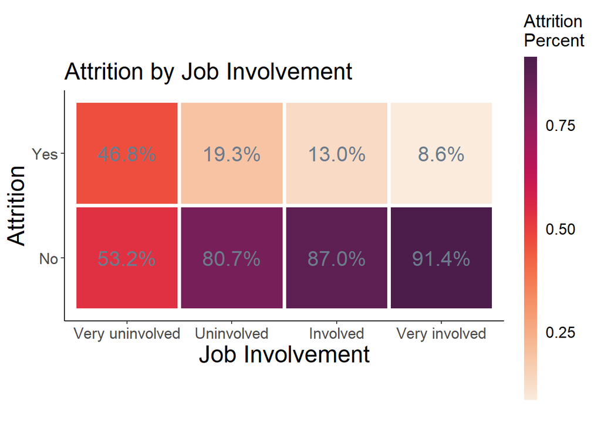

```r
ggplot(attr.ji, aes(x=JobInvolvement, y=Attrition, fill=perc)) +
  geom_tile(color = "white", lwd = 1.5, linetype = 1) + geom_text(aes(label
  = scales::percent(perc)), color = "slategray4", size = 6) + coord_fixed()+
  labs(title='Attrition by Job Involvement', x='Job Involvement') +
  theme(axis.text = element_text(size = 13), axis.title = element_text(size
  = 20), plot.title = element_text(size= 20), legend.title =
  element_text(size = 15), legend.text = element_text(size = 13),
  panel.background = element_blank(), axis.line = element_line(colour =
  "black")) + guides(fill = guide_colourbar(title='Attrition \nPercent',
  ticks = FALSE, barwidth = .75, barheight = 20)) +
  scale_fill_viridis(option='F', begin=.2, direction=-1)
```

### Identify job role trends

Display monthly salary for each role and their attrition rate. Attrition is high for lower salary. This does not surprise us but is there another driving force? Display the rate of lowest job satisfaction for each job role. We concluded that higher paying roles have higher dissatisfaction yet lower attrition rate thus salary is the biggest driver behind attrition for job roles.

Set up dataframe

```r
role <- attr %>% select(attr10, JobRole, JobSatisfaction, MonthlyIncome)
role.attr <- aggregate(attr10~JobRole, data=role, mean)
role.attr <- arrange(role.attr, attr10)
levels <- role.attr$JobRole
role$JobRole <- factor(role$JobRole, levels = levels)
role.attr
```

```
##                     JobRole     attr10
## 1         Research Director 0.01960784
## 2    Manufacturing Director 0.02298851
## 3                   Manager 0.07843137
## 4 Healthcare Representative 0.10526316
## 5           Sales Executive 0.16500000
## 6        Research Scientist 0.18604651
## 7     Laboratory Technician 0.19607843
## 8           Human Resources 0.22222222
## 9      Sales Representative 0.45283019
```

Plot monthly income by job role

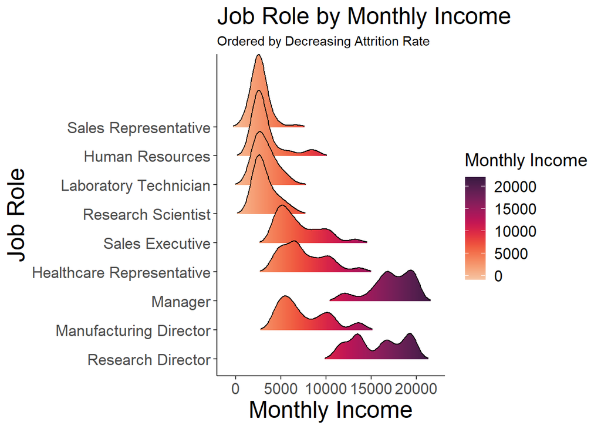

```r
ggplot(role, aes(x = MonthlyIncome, y = JobRole, fill = stat(x))) +
  geom_density_ridges_gradient(scale = 2.5, rel_min_height = 0.01) +
  scale_fill_viridis(name = "Monthly Income", option = "F", direction=-1,
  begin=.15, end=.9) + labs(title='Job Role by Monthly Income', subtitle =
  'Ordered by Decreasing Attrition Rate', x='Monthly Income', y='Job Role')+
  theme(axis.text = element_text(size = 13), axis.title = element_text(size
  = 20), plot.title = element_text(size= 20), legend.title =
  element_text(size = 15), legend.text = element_text(size = 13),
  panel.background = element_blank(), axis.line = element_line(colour =
  "black"))
```

Job satisfaction: Replace all 1 with Very Unsatisfied, 2 Unsatisfied, 3 Satisfied, 4 Very Satisfied

```r
role$JobSatisfaction <- ifelse(role$JobSatisfaction == 1, 'Very unsatisfied', role$JobSatisfaction)
role$JobSatisfaction <- ifelse(role$JobSatisfaction == 2, 'Unsatisfied', role$JobSatisfaction)
role$JobSatisfaction <- ifelse(role$JobSatisfaction == 3, 'Satisfied', role$JobSatisfaction)
role$JobSatisfaction <- ifelse(role$JobSatisfaction == 4, 'Very satisfied', role$JobSatisfaction)
```

Calculate rate of lowest job satisfaction by job role

```r
role.satis <-  role %>% count(JobSatisfaction, JobRole)
role.satis <- pivot_wider(role.satis, names_from = JobSatisfaction, values_from = n)
role.satis <- role.satis %>% mutate(sum = rowSums(role.satis[,c(2:5)], na.rm=TRUE), perc=`Very unsatisfied`/sum)
arrange(role.satis, -perc)
```

```
## # A tibble: 9 x 7
##   JobRole    Satisfied Unsatisfied `Very satisfied` `Very unsatisfi~   sum  perc
##   <fct>          <int>       <int>            <int>            <int> <dbl> <dbl>
## 1 Research ~        16          11               11               13    51 0.255
## 2 Sales Exe~        61          25               66               48   200 0.24
## 3 Manager           12          14               13               12    51 0.235
## 4 Healthcar~        23           9               28               16    76 0.211
## 5 Laborator~        43          31               47               32   153 0.209
## 6 Research ~        48          31               61               32   172 0.186
## 7 Human Res~         8           8                6                5    27 0.185
## 8 Sales Rep~        14          14               16                9    53 0.170
## 9 Manufactu~        29          23               23               12    87 0.138
```

## Prediction

### Conduct naive bayes to predict attrition rate

Build the model using the full data then validate model with 75/25 split of train/test. Benchmark to reach is 60% sensitivity, 60% specificity, and significant p-value of below alpha = .05. Used provided dataset that did not include attrition result to predict attrition rate and export results to be submitted.

1. Variables set as factor

```r
attr$Attrition <- as.factor(attr$Attrition)
attr$OverTime <- as.factor(attr$OverTime)
#attr$JobInvolvement <- as.factor(attr$JobInvolvement)
#attr$JobLevel <- as.factor(attr$JobLevel)
#attr$WorkLifeBalance <- as.factor(attr$WorkLifeBalance)
attr$EnvironmentSatisfaction<- as.factor(attr$EnvironmentSatisfaction)
#attr$StockOptionLevel<- as.factor(attr$StockOptionLevel)
attr$Education <- as.factor(attr$Education)
#attr$JobSatisfaction <- as.factor(attr$JobSatisfaction)
attr$RelationshipSatisfaction<- as.factor(attr$RelationshipSatisfaction)
attr$EducationField <- as.factor(attr$EducationField)
attr$Department <- as.factor(attr$Department)
attr$JobRole <- as.factor(attr$JobRole)
attr$MaritalStatus <- as.factor(attr$MaritalStatus)
attr$BusinessTravel <- as.factor(attr$BusinessTravel)
attr$Gender <- as.factor(attr$Gender)
```

2. Build the Naive Bayes model using all the variables excluding the 12 listed Accuracy = 86% Sensi = 61.42% Speci = 90.82%

```r
set.seed(80)
nb <- naiveBayes(Attrition~.-ID-Attrition-BusinessTravel-DailyRate-HourlyRate-MonthlyRate-Education-EducationField-Gender-YearsWithCurrManager-YearsAtCompany-YearsSinceLastPromotion, data = attr)
p <- predict(nb, attr)
cm <- confusionMatrix(p, attr$Attrition, positive = 'Yes')
c(cm$overall['Accuracy'], cm$overall['AccuracyPValue'], cm$byClass[1], cm$byClass[2])
```

```
##       Accuracy AccuracyPValue    Sensitivity    Specificity
##     0.86091954     0.04195486     0.61428571     0.90821918
```

3. Validate the model with 75/25 train/test split May have to rerun a few times, average sensi was 60% low of 45 high of 75 Accuracy = 87.61% Sensi = 59.45% Speci = 93.37%

```r
model.attr <- sample(1:nrow(attr), round(.75*nrow(attr)))
train.attr <- attr[model.attr,]
test.attr <- attr[-model.attr,]
nb.train <- naiveBayes(Attrition~.-ID-Attrition-BusinessTravel-DailyRate-HourlyRate-MonthlyRate-Education-EducationField-Gender-YearsWithCurrManager-YearsAtCompany-YearsSinceLastPromotion, data = train.attr)
p.train <- predict(nb.train, test.attr)
cm.test <- confusionMatrix(p.train, test.attr$Attrition, positive = 'Yes')
c(cm.test$overall['Accuracy'], cm.test$overall['AccuracyPValue'], cm.test$byClass[1], cm.test$byClass[2])
```

```
##       Accuracy AccuracyPValue    Sensitivity    Specificity
##     0.87614679     0.03929308     0.59459459     0.93370166
```

4. Predict attrition with provided data that does not include attrition result

Read in the data

```r
train.attr <- read_csv('https://raw.githubusercontent.com/ReuvenDerner/CaseStudy2DDS/main/CaseStudy2CompSet%20No%20Attrition.csv', show_col_types=F)
```

Predict attrition and export

```r
p.attr <- predict(nb, newdata = train.attr)
p.attr.df <- data.frame(ID = train.attr$ID, Attrition = p.attr)
head(p.attr.df)
write.csv(p.attr.df,"C:\\Users\\Robert.Derner\\Desktop\\Case2PredictionsLamDernerAttrition.csv", row.names = FALSE)
```

[output not shown]

### Conduct linear regression to predict monthly salary

1. Build the model using job level, job role, and total working years

```r
set.seed(100)
fit.sal <- lm(MonthlyIncome~TotalWorkingYears+JobLevel+JobRole, data=attr)
summary(fit.sal)
```

```
##
## Call:
## lm(formula = MonthlyIncome ~ TotalWorkingYears + JobLevel + JobRole,
##     data = attr)
##
## Residuals:
##     Min      1Q  Median      3Q     Max
## -3989.9  -631.3    -9.4   616.8  4144.6
##
## Coefficients:
##                               Estimate Std. Error t value Pr(>|t|)
## (Intercept)                   -103.243    203.291  -0.508  0.61168
## TotalWorkingYears               47.998      7.951   6.037 2.34e-09 ***
## JobLevel                      2795.329     81.784  34.179  < 2e-16 ***
## JobRoleHuman Resources        -321.962    251.744  -1.279  0.20127
## JobRoleLaboratory Technician  -597.329    168.984  -3.535  0.00043 ***
## JobRoleManager                4002.415    228.696  17.501  < 2e-16 ***
## JobRoleManufacturing Director  137.309    167.212   0.821  0.41178
## JobRoleResearch Director      3993.674    214.342  18.632  < 2e-16 ***
## JobRoleResearch Scientist     -324.522    169.387  -1.916  0.05572 .
## JobRoleSales Executive         -66.048    144.221  -0.458  0.64709
## JobRoleSales Representative   -410.303    211.660  -1.939  0.05289 .
## ---
## Signif. codes:  0 '***' 0.001 '**' 0.01 '*' 0.05 '.' 0.1 ' ' 1
##
## Residual standard error: 1063 on 859 degrees of freedom
## Multiple R-squared:  0.9472, Adjusted R-squared:  0.9466
## F-statistic:  1541 on 10 and 859 DF,  p-value: < 2.2e-16
```

```r
ols_regress(MonthlyIncome~TotalWorkingYears+JobLevel+JobRole, data=attr)
```

```
##                            Model Summary
## -------------------------------------------------------------------
## R                       0.973       RMSE                  1062.757
## R-Squared               0.947       Coef. Var               16.631
## Adj. R-Squared          0.947       MSE                1129452.420
## Pred R-Squared          0.946       MAE                    805.151
## -------------------------------------------------------------------
##  RMSE: Root Mean Square Error
##  MSE: Mean Square Error
##  MAE: Mean Absolute Error
##
##                                       ANOVA
## ---------------------------------------------------------------------------------
##                        Sum of
##                       Squares         DF       Mean Square       F          Sig.
## ---------------------------------------------------------------------------------
## Regression    17399424758.568         10    1739942475.857    1540.519    0.0000
## Residual        970199628.628        859       1129452.420
## Total         18369624387.195        869
## ---------------------------------------------------------------------------------
##
##                                               Parameter Estimates
## ----------------------------------------------------------------------------------------------------------------
##                         model        Beta    Std. Error    Std. Beta      t        Sig        lower       upper
## ----------------------------------------------------------------------------------------------------------------
##                   (Intercept)    -103.243       203.291                 -0.508    0.612    -502.248     295.761
##             TotalWorkingYears      47.998         7.951        0.078     6.037    0.000      32.393      63.604
##                      JobLevel    2795.329        81.784        0.663    34.179    0.000    2634.809    2955.848
##        JobRoleHuman Resources    -321.962       251.744       -0.012    -1.279    0.201    -816.066     172.143
##  JobRoleLaboratory Technician    -597.329       168.984       -0.049    -3.535    0.000    -928.999    -265.658
##                JobRoleManager    4002.415       228.696        0.205    17.501    0.000    3553.547    4451.283
## JobRoleManufacturing Director     137.309       167.212        0.009     0.821    0.412    -190.882     465.500
##      JobRoleResearch Director    3993.674       214.342        0.204    18.632    0.000    3572.979    4414.368
##     JobRoleResearch Scientist    -324.522       169.387       -0.028    -1.916    0.056    -656.983       7.940
##        JobRoleSales Executive     -66.048       144.221       -0.006    -0.458    0.647    -349.114     217.018
##   JobRoleSales Representative    -410.303       211.660       -0.021    -1.939    0.053    -825.735       5.128
## ----------------------------------------------------------------------------------------------------------------
```

```r
c(RMSE = 1062.757, R2=summary(fit.sal)$r.squared)
```

```
##         RMSE           R2
## 1062.7570000    0.9471846
```

Model Diagnostics

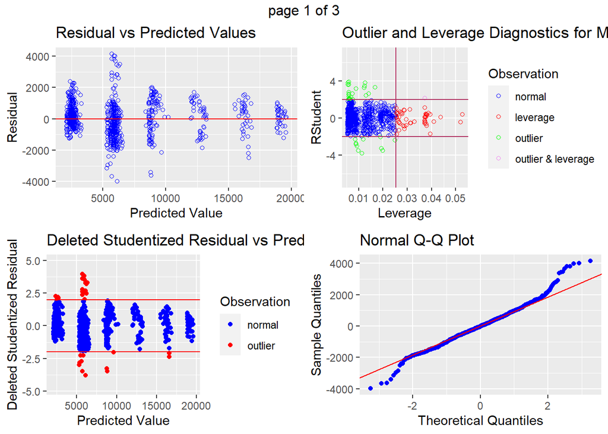

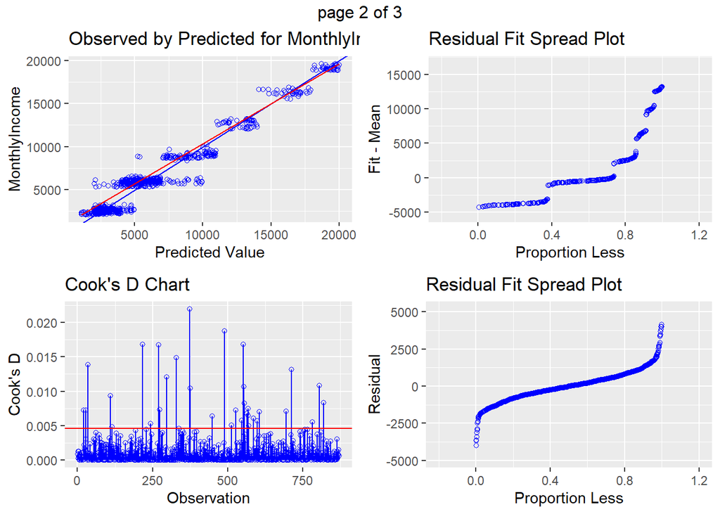

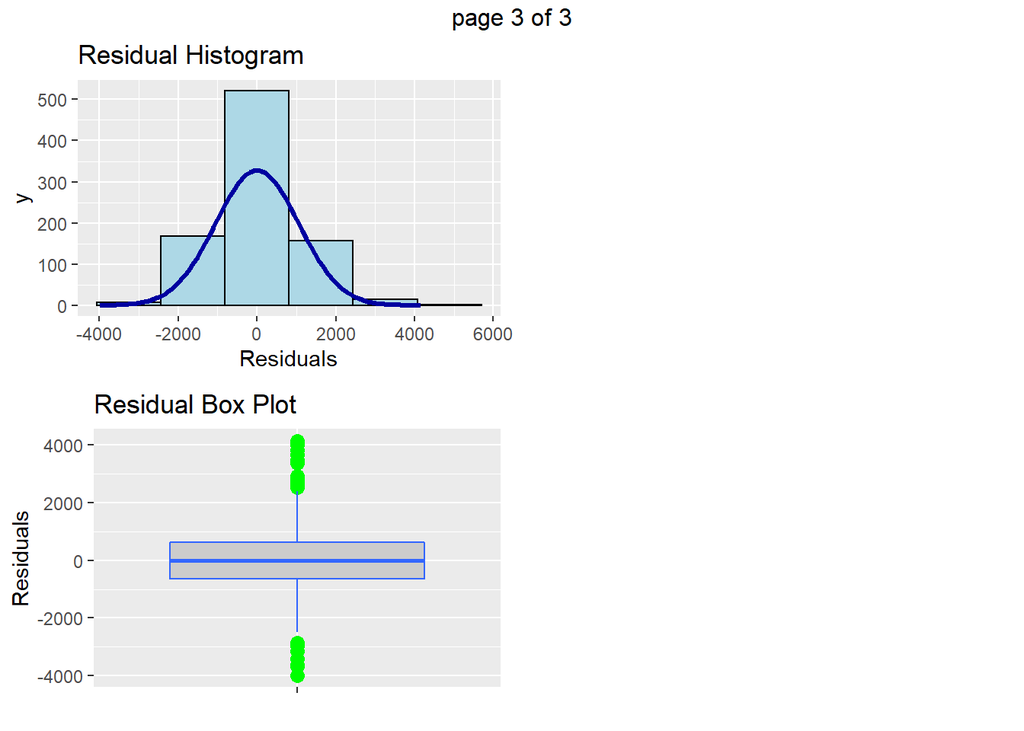

```r
ols_plot_diagnostics(fit.sal) # all diagnostic plots
```

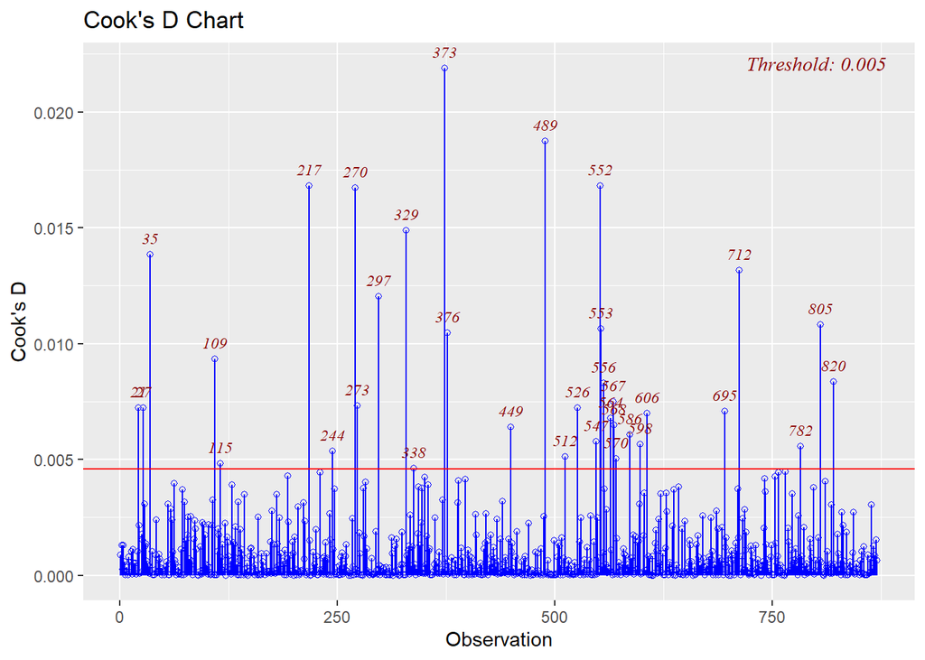

```r
ols_plot_cooksd_chart(fit.sal) # cooks d
```

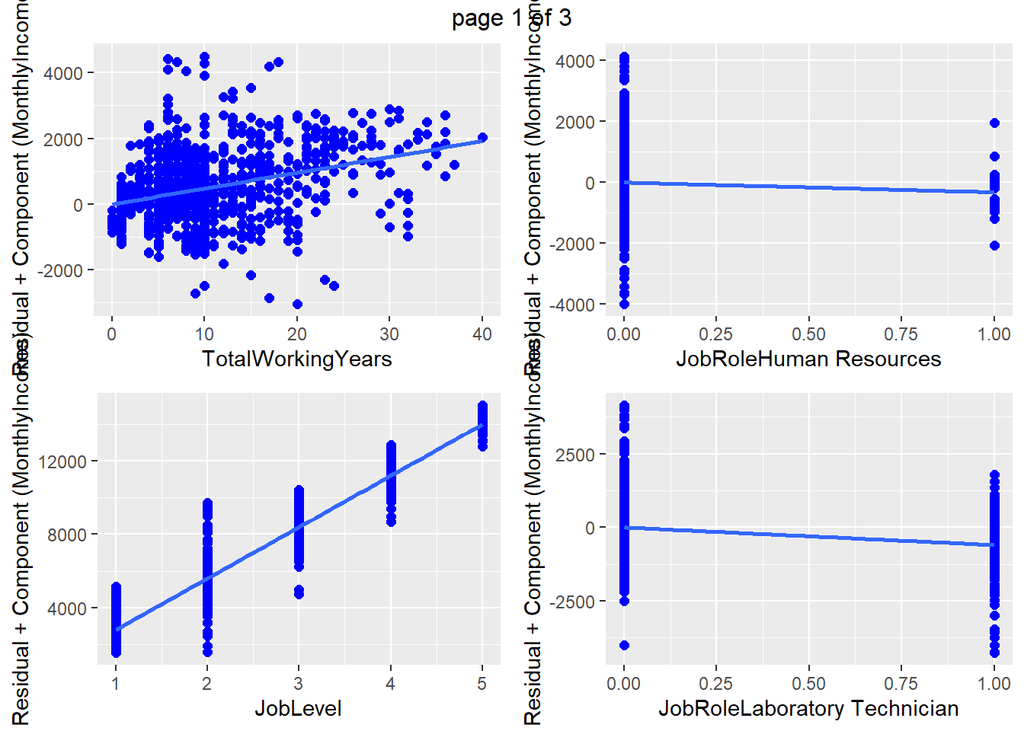

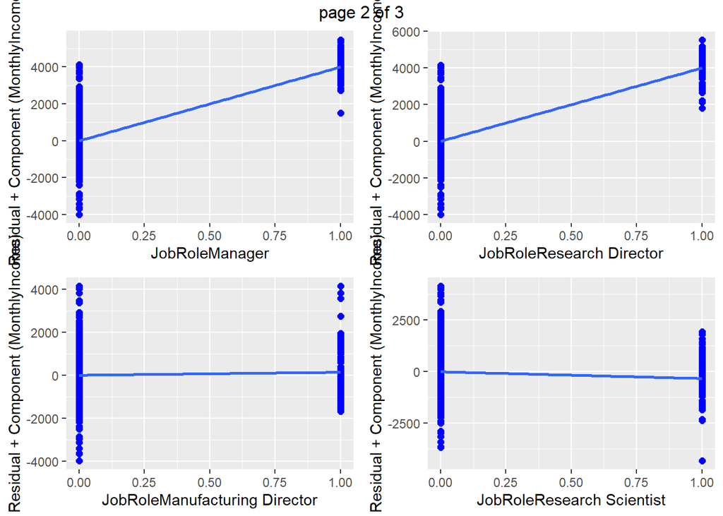

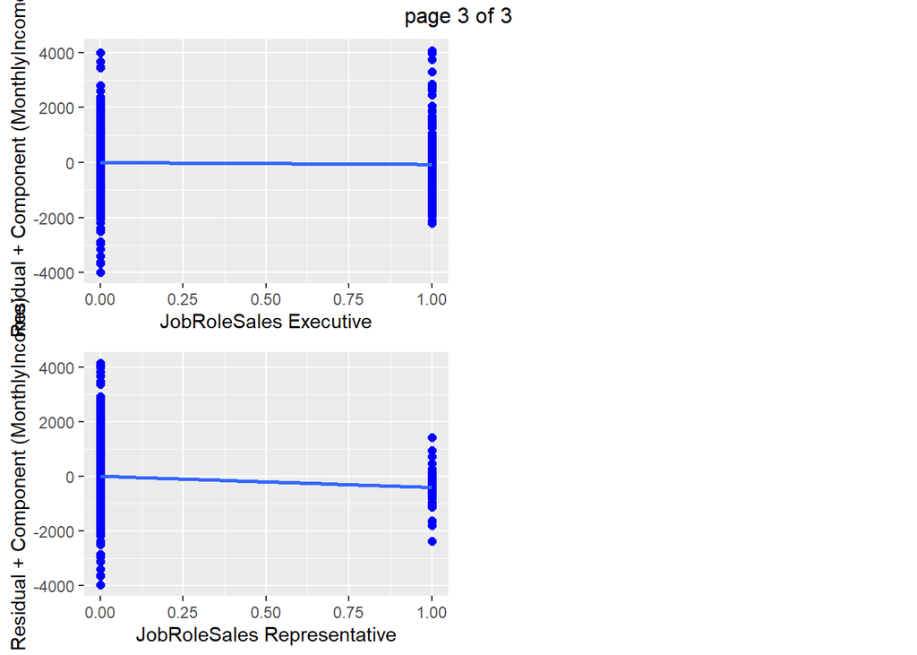

```r
ols_plot_comp_plus_resid(fit.sal)
```

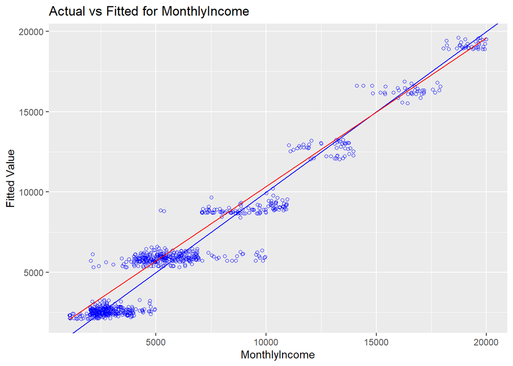

```r
ols_plot_obs_fit(fit.sal) # actual vs fitted values
```

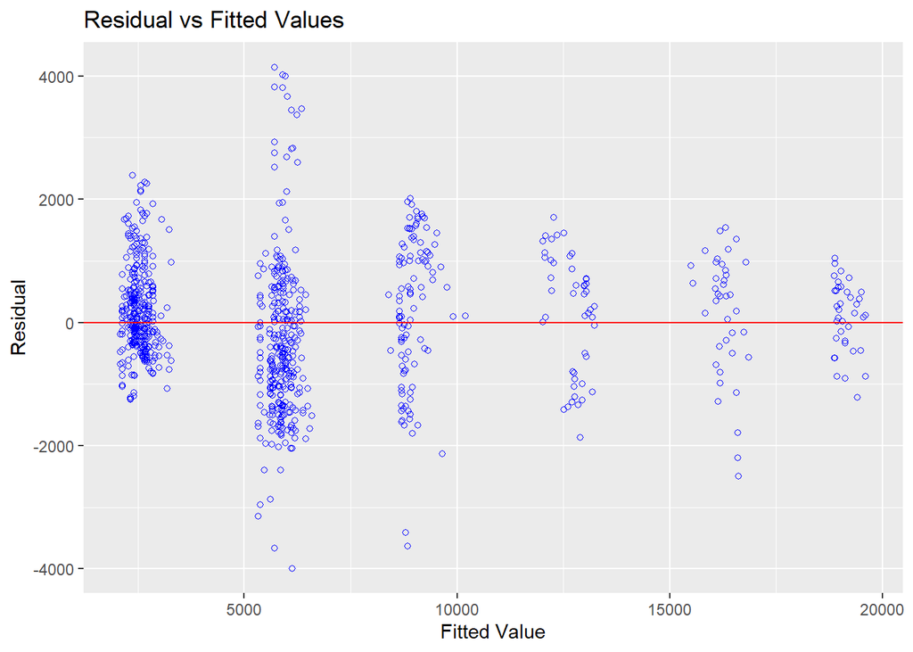

```r
ols_plot_resid_fit(fit.sal) # residual vs fitted values
```

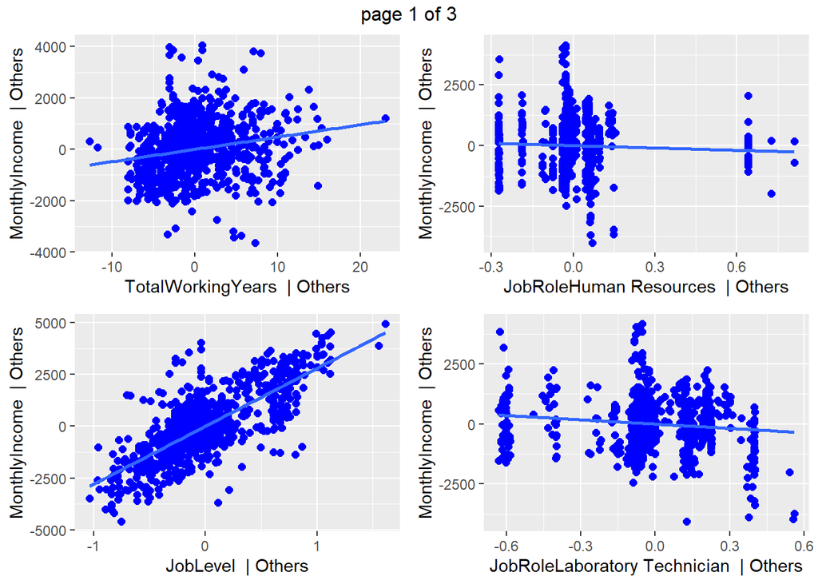

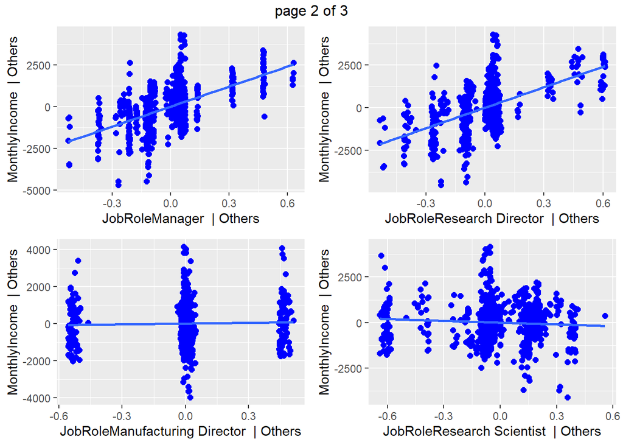

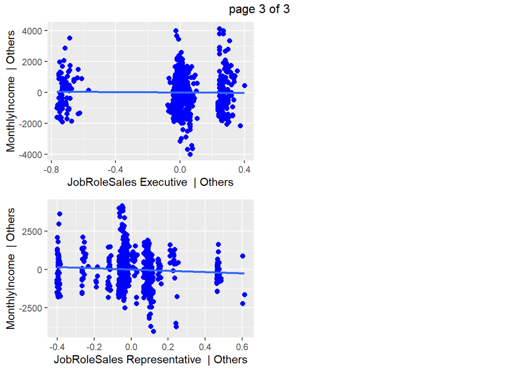

```r
ols_plot_added_variable(fit.sal) # partial residuals / added variable
```

```r
attr$JobLevel <- as.factor(attr$JobLevel)
attr$JobRole <- relevel(attr$JobRole, ref='Manufacturing Director')
fit.sal <- lm(MonthlyIncome~TotalWorkingYears+JobLevel+JobRole, data=attr)
```

2. Validate the model with 70/30 train/test split

```r
model <- sample(1:nrow(attr), round(.7*nrow(attr)))
train <- attr[model,]
test <- attr[-model,]
fit.sal.train <- lm(MonthlyIncome~TotalWorkingYears+JobLevel+JobRole, data=train)
summary(fit.sal.train)
```

```
##
## Call:
## lm(formula = MonthlyIncome ~ TotalWorkingYears + JobLevel + JobRole,
##     data = train)
##
## Residuals:
##     Min      1Q  Median      3Q     Max
## -2954.9  -623.0   -96.5   613.4  4243.0
##
## Coefficients:
##                                   Estimate Std. Error t value Pr(>|t|)
## (Intercept)                       3724.760    210.841  17.666  < 2e-16 ***
## TotalWorkingYears                   39.052      9.489   4.115 4.41e-05 ***
## JobLevel2                         1738.921    168.941  10.293  < 2e-16 ***
## JobLevel3                         4908.763    227.859  21.543  < 2e-16 ***
## JobLevel4                         8424.471    347.722  24.228  < 2e-16 ***
## JobLevel5                        11129.337    407.865  27.287  < 2e-16 ***
## JobRoleHealthcare Representative   -86.711    198.912  -0.436 0.663047
## JobRoleHuman Resources           -1199.015    320.706  -3.739 0.000203 ***
## JobRoleLaboratory Technician     -1413.788    205.913  -6.866 1.67e-11 ***
## JobRoleManager                    3313.273    298.180  11.112  < 2e-16 ***
## JobRoleResearch Director          3392.346    264.932  12.805  < 2e-16 ***
## JobRoleResearch Scientist        -1156.798    213.828  -5.410 9.15e-08 ***
## JobRoleSales Executive             -86.992    161.292  -0.539 0.589850
## JobRoleSales Representative      -1339.315    261.544  -5.121 4.11e-07 ***
## ---
## Signif. codes:  0 '***' 0.001 '**' 0.01 '*' 0.05 '.' 0.1 ' ' 1
##
## Residual standard error: 1039 on 595 degrees of freedom
## Multiple R-squared:  0.9516, Adjusted R-squared:  0.9505
## F-statistic: 899.8 on 13 and 595 DF,  p-value: < 2.2e-16
```

```r
p.test <- predict(fit.sal.train, newdata=test, type='response')
error <- test$MonthlyIncome-p.test
rmse <- sqrt(mean(error^2))
c(RMSE = rmse, R2=summary(fit.sal.train)$r.squared)
```

```
##        RMSE          R2
## 940.7227218   0.9515969
```

Read the train data

```r
train.salary <- read_csv('https://raw.githubusercontent.com/ReuvenDerner/CaseStudy2DDS/main/CaseStudy2CompSetNoSalary.csv', show_col_types = F)
```

Predict salary and export

```r
p.salary <- predict(fit.sal, newdata = train.salary, type = 'response')
p.salary
p.sal.df <- data.frame(ID = train.salary$ID, MonthlyIncome = p.salary)
head(p.sal.df)
write.csv(p.sal.df,"C:\\Users\\Robert.Derner\\Desktop\\Case2PredictionsLamDernerSalary.csv", row.names = FALSE)
```

[output not shown]